# Member versus Casual Final Project

2022-12-2

##Website used to compare where the “touristy” areas are = https://www.flickr.com/photos/walkingsf/4672195208

- Blue dots represent where pictures are taken by locals
- Red dots represent where pictures are taken by tourists
- Yellow dots could be from either

## Install lehdr

Run this code only once.

```r
#devtools::install_github("jamgreen/lehdr")
```

## Packages

```r
library(knitr)
library(tidyverse)
library(janitor)
library(lubridate)
library(here)
library(sf)
library(tmap)
library(tidycensus)
library(lehdr)
library(rnaturalearth)
library(WDI)
library(tigris)
library(rgdal)
library(sp)
library(dsbox)
```

## Downloading Census Data

Key points -Downloading basic census data with the geography and population of DC in 2021 -Turn census data wide to get population data as a column

```r
census_api_key("d44395e2fa101f82260fae6b845676d71f017b70")
```

```
To install your API key for use in future sessions, run this function with `install = TRUE`.
```

```r
census=get_acs(geography = "tract",
               variables = c("pop"="B01001_001"),
               state="DC", geometry = TRUE,year=2021)
```

```
Downloading feature geometry from the Census website.  To cache shapefiles for use in future sessions, set `options(tigris_use_cache = TRUE)`.
```

```r
census_wide = census %>% select(-moe) %>% spread(variable, estimate) %>%
  select(GEOID, pop, geometry) %>% st_transform(4326)
```

## Downloading Bike Data

```r
bikeshare = read_csv("202209-capitalbikeshare-tripdata.csv") %>% clean_names()
bikeshare_start = bikeshare %>% select(member_casual, start_lng, start_lat) %>% st_as_sf(coords=c("start_lng","start_lat"), crs=st_crs(census_wide))

bikeshare_start_member = bikeshare_start %>% filter(member_casual == "member")

tot_member = nrow(bikeshare_start_member)

bikeshare_start_casual = bikeshare_start %>% filter(member_casual == "casual")

tot_casual = nrow(bikeshare_start_casual)

bike_census = census_wide %>% mutate(start_count_member = lengths(st_intersects(., bikeshare_start_member))) %>% mutate(start_count_member_perc = start_count_member/tot_member)

bike_census = bike_census %>% mutate(start_count_casual = lengths(st_intersects(., bikeshare_start_casual))) %>% mutate(start_count_casual_perc = start_count_casual/tot_casual)
```

```r
tot_casual
```

```
[1] 156590
```

```r
tot_member
```

```
[1] 229495
```

# Plot Our Data

```r
tmap_mode("view")
```

```
tmap mode set to interactive viewing
```

```r
tm_shape(bike_census) + tm_polygons(c("start_count_member_perc","start_count_casual_perc"))
```

[interactive chart not shown]

##Observations

From looking at the graphs above, you can see that casual riders (which are usually tourists), are riding way more often in area “11001980000” which is where all the tourist attractions and sight-seeing places are.

However the member percentage is more spread out into other parts of D.C. because these are local people using the bike share program to get to and from work, or go about their daily activities.

Our hypothesis that the spatial pattern of members vs causal riders would show casual riders more condensed in one area was correct.

## Lincoln Monument Coordinates

```r
linc_long <- -77.0502
linc_lat <- 38.8893
linc <- data.frame(linc_lat,linc_long)
```

## Link Lincoln monument data with bike data

Key Points -Take bikeshare data and select status and coordinates -Create a data set for the Lincoln monument data -Join these data sets so we can do calculations on the two

```r
boxp1 <- bikeshare %>% select(member_casual, start_lng, start_lat) %>% sample_n(1000)

boxp <- boxp1 %>% mutate(lat_linc = start_lng) %>% mutate(long_linc = lat_linc) %>% select(lat_linc, long_linc, member_casual) %>% sample_n(1000)

boxp[,'lat_linc'] = linc_lat
boxp[,'long_linc'] = linc_long

boxp2 <- left_join(boxp, boxp1, by = 'member_casual') %>% sample_n(1000)
```

## Using haversine function - from Coach Skufca

```r
haversine <- function(long1, lat1, long2, lat2, round = 3) {
  # convert to radians
  long1 = long1 * pi / 180
  lat1  = lat1  * pi / 180
  long2 = long2 * pi / 180
  lat2  = lat2  * pi / 180

  R = 6371 # Earth mean radius in km

  a = sin((lat2 - lat1)/2)^2 + cos(lat1) * cos(lat2) * sin((long2 - long1)/2)^2
  d = R * 2 * asin(sqrt(a))

  return( round(d,round) ) # distance in km
}
```

## Distance from Lincoln Memorial

```r
linc_dist <- boxp2 %>% mutate(distance = haversine(start_lng, start_lat, long_linc, lat_linc, round = 4))
```

## Boxplot

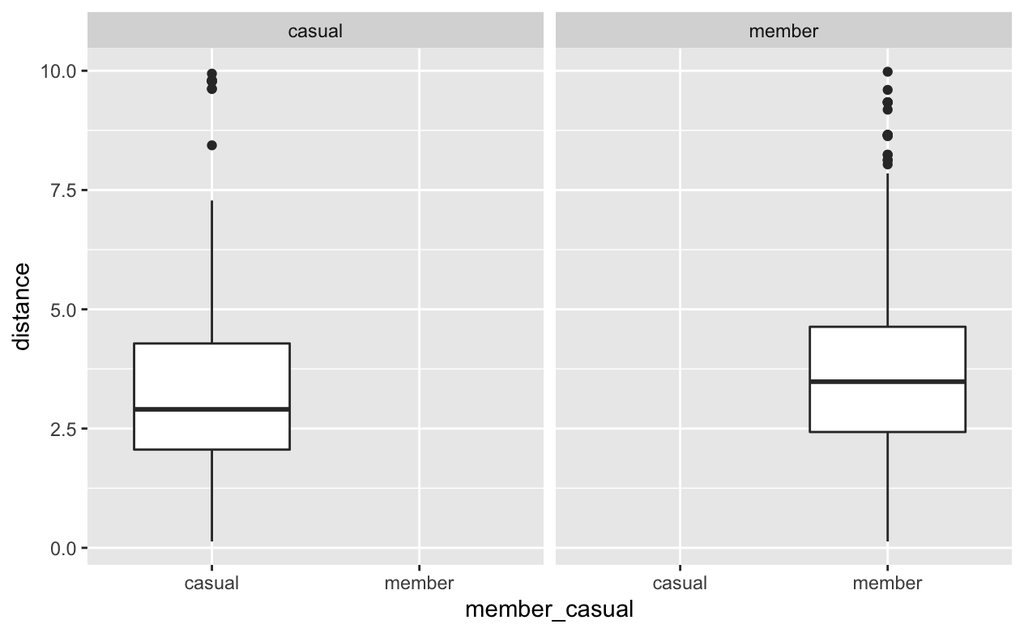

```r
df <- linc_dist %>% select(distance, member_casual) %>% filter(distance < 10)
ggplot(data = df)+
  geom_boxplot(aes(x= member_casual, y = distance)) + facet_wrap(~member_casual)
```

##Boxplot Observations

This further proves the analysis gotten from the graphs above. The “distance” label describes the distance between the bike ride taken from the Lincoln Memorial. We found the distance relative to the Lincoln Memorial because it is in the touristy area, so in theory the causal riders should have closer distances to the memorial than the members. This is shown in the box and whisker plot above. Also you can see that there are more instances of member bike rides being much further away from the memorial.